# Module 5.2 - Developing and Hosting OGC Services - OGC Services and Styling in GeoServer - Part I

### Overview

- GeoServer Styled Layer Descriptor (SLD) Foundation: OGC Specification
- Creation and Management of Styles in GeoServer
  - Definition of Styles
  - Base Styles
  - Basic New Styles
  - Basic Filters

## OGC Styled Layer Descriptor (SLD)

### OGC Styled Layer Descriptor (SLD)

- GeoServer uses the OGC standard for definition of symbolization both for user and server definition ([OGC SLD Standard](http://www.opengeospatial.org/standards/sld))
- Most, but not all of the OGC standard has been implemented with GeoServer
- The materials presented here are based upon the SLD reference distributed as part of the [Current GeoServer HTML documentation](http://docs.geoserver.org/stable/en/user/index.html), and in particular the [GeoServer SLD Cookbook](http://docs.geoserver.org/stable/en/user/styling/sld-cookbook/index.html).

### Definition of Styles

Styles are XML documents that conform to the OGC SLD standard, and consist of four major components

**Symbolizers**

SLD components that define the rendering style of specific types of content

- [Point](http://docs.geoserver.org/stable/en/user/styling/sld-reference/pointsymbolizer.html)
- [Line](http://docs.geoserver.org/stable/en/user/styling/sld-reference/linesymbolizer.html)
- [Polygon](http://docs.geoserver.org/stable/en/user/styling/sld-reference/polygonsymbolizer.html)
- [Raster](http://docs.geoserver.org/stable/en/user/styling/sld-reference/rastersymbolizer.html)
- [Text](http://docs.geoserver.org/stable/en/user/styling/sld-reference/textsymbolizer.html)

### Definition of Styles - cont.

**Labels**

Defining the placement of [labels](http://docs.geoserver.org/stable/en/user/styling/sld-reference/labeling.html)

**Filters**

Allow for the application different symbolizers to [defined sets](http://docs.geoserver.org/stable/en/user/styling/sld-reference/filters.html) of features

**Scale Elements**

Allow for the application of different symbolizers at different map scales through the definition of [styling rules](http://docs.geoserver.org/stable/en/user/styling/sld-reference/rules.html)

### Definition of Styles - Header Content

```xml
<?xml version="1.0" encoding="ISO-8859-1"?>
<StyledLayerDescriptor version="1.0.0"
  xsi:schemaLocation="http://www.opengis.net/sld StyledLayerDescriptor.xsd"
  xmlns="http://www.opengis.net/sld"
  xmlns:ogc="http://www.opengis.net/ogc"
  xmlns:xlink="http://www.w3.org/1999/xlink"
  xmlns:xsi="http://www.w3.org/2001/XMLSchema-instance">

one or more <NamedLayer> ...  </NamedLayer> elements

</StyledLayerDescriptor>
```

### Definition of Styles - Sample SLD File

```xml
<?xml version="1.0" encoding="ISO-8859-1"?>
<StyledLayerDescriptor version="1.0.0"
  xsi:schemaLocation="http://www.opengis.net/sld StyledLayerDescriptor.xsd"
  xmlns="http://www.opengis.net/sld"
  xmlns:ogc="http://www.opengis.net/ogc"
  xmlns:xlink="http://www.w3.org/1999/xlink"
  xmlns:xsi="http://www.w3.org/2001/XMLSchema-instance">
  <NamedLayer>
    <Name>Simple Point</Name>
    <UserStyle>
      <Title>SLD Cook Book: Simple Point With Stroke</Title>
      <FeatureTypeStyle>
        <Rule>
          <PointSymbolizer>
            <Graphic>
              <Mark>
                <WellKnownName>circle</WellKnownName>
                <Fill>
                  <CssParameter name="fill">#FF0000</CssParameter>
                </Fill>
              </Mark>
              <Size>6</Size>
            </Graphic>
          </PointSymbolizer>
        </Rule>
      </FeatureTypeStyle>
    </UserStyle>
  </NamedLayer>
</StyledLayerDescriptor>
```

### Simple GeoServer Point Style

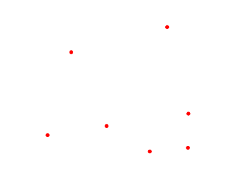

SLD Snippet ([Full SLD](http://karlbenedict.com/GEOG485-585/lectures/examples/sld_cookbook/point_simplepoint.sld))

```xml
<NamedLayer>
  <Name>Simple Point</Name>
  <UserStyle>
    <Title>SLD Cook Book: Simple Point With Stroke</Title>
    <FeatureTypeStyle>
      <Rule>
        <PointSymbolizer>
          <Graphic>
            <Mark>
              <WellKnownName>circle</WellKnownName>
              <Fill>
                <CssParameter name="fill">#FF0000</CssParameter>
              </Fill>
            </Mark>
            <Size>6</Size>
          </Graphic>
        </PointSymbolizer>
      </Rule>
    </FeatureTypeStyle>
  </UserStyle>
</NamedLayer>
```

### Simple GeoServer Line Style

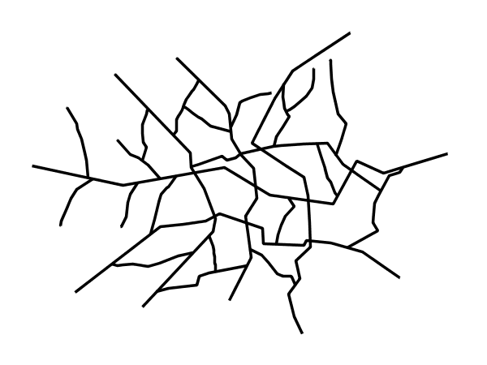

SLD Snippet ([Full SLD](http://karlbenedict.com/GEOG485-585/lectures/examples/sld_cookbook/line_simpleline.sld))

```xml
<NamedLayer>
  <Name>Simple Line</Name>
  <UserStyle>
    <Title>SLD Cook Book: Simple Line</Title>
    <FeatureTypeStyle>
      <Rule>
        <LineSymbolizer>
          <Stroke>
            <CssParameter name="stroke">#000000</CssParameter>
            <CssParameter name="stroke-width">3</CssParameter>
          </Stroke>
        </LineSymbolizer>
      </Rule>
    </FeatureTypeStyle>
  </UserStyle>
</NamedLayer>
```

### Simple GeoServer Polygon Style

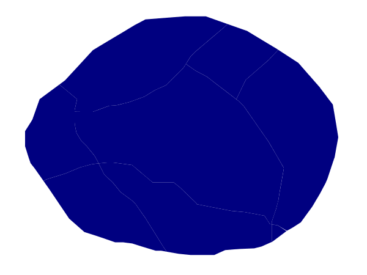

SLD Snippet ([Full SLD](http://karlbenedict.com/GEOG485-585/lectures/examples/sld_cookbook/polygon_simplepolygon.sld))

```xml
<NamedLayer>
  <Name>Simple polygon</Name>
  <UserStyle>
    <Title>SLD Cook Book: Simple polygon</Title>
    <FeatureTypeStyle>
      <Rule>
        <PolygonSymbolizer>
          <Fill>
            <CssParameter name="fill">#000080</CssParameter>
          </Fill>
        </PolygonSymbolizer>
      </Rule>
    </FeatureTypeStyle>
  </UserStyle>
</NamedLayer>
```

### Simple GeoServer Raster Style

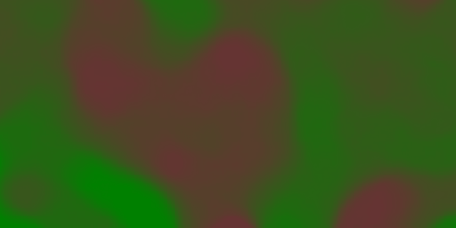

SLD Snippet ([Full SLD](http://karlbenedict.com/GEOG485-585/lectures/examples/sld_cookbook/raster_twocolorgradient.sld))

```xml
<NamedLayer>
  <Name>Two color gradient</Name>
  <UserStyle>
    <Title>SLD Cook Book: Two color gradient</Title>
      <FeatureTypeStyle>
        <Rule>
          <RasterSymbolizer>
            <ColorMap>
              <ColorMapEntry color="#008000"
                quantity="70" />
              <ColorMapEntry color="#663333"
                quantity="256" />
            </ColorMap>
          </RasterSymbolizer>
        </Rule>
      </FeatureTypeStyle>
  </UserStyle>
</NamedLayer>
```

### PointSymbolizer

```xml
<Graphic>
  <ExternalGraphic>
    <OnlineResource> (Required)
    <Format>
  <Mark>
    <WellKnownName> (Required)
    <Fill>
    <Stroke>
    <Opacity>
    <Size>
    <Rotation>
```

### LineSybolizer

```xml
<Stroke>
  <GraphicFill>
    <Graphic> contents same as PointSymbolizer
  <GraphicStroke>
    <Graphic> contents same as PointSymbolizer
  <CssParameter name="...">
    name="stroke"
    name="stroke-width"
    name="stroke-opacity"
    name="stroke-linejoin"
    name="stroke-linecap"
    name="stroke-dasharray"
    name="stroke-dashoffset"
```

### PolygonSymbolizer

```xml
<Fill>
  <GraphicFill>
    <Graphic> contents same as PointSymbolizer
  <CssParameter name="...">
    name="fill"
    name="fill-opacity"
  <Stroke> same as the LineSymbolizer
```

### Raster Symbolizer

```xml
<Opacity>
<ColorMap type="ramp | values | intervals" extended="true | false">
  <ColorMapEntry color="" quantity="" label="" opacity=""/>
<ChannelSelection>
  <RedChannel> <GreenChannel> <BlueChannel>
    <SourceChannelName>
  <GrayChannel>
    <SourceChannelName>
<ContrastEnhancement>
<ShadedRelief> (not implemented in ver 2.0)
<OverlapBehavior> (not implemented in ver 2.0)
<ImageOutline> (not implemented in ver 2.0)
```

## Filters

### SLD Filter Rules and Vector Symbolization

Filters based upon Attribute Values

```
<PropertyIsEqualTo>
<PropertyIsNotEqualTo>
<PropertyIsLessThan>
<PropertyIsLessThanOrEqualTo>
<PropertyIsGreaterThan>
<PropertyIsGreaterThanOrEqualTo>
<PropertyIsBetween>
```

Logical Filters - for combining multiple filters

```
<And>
<Or>
<Not>
```

### SLD Filter Rules and Vector Symbolization - cont.

Spatial Filters

```
<Intersects>
<Equals>
<Disjoint>
<Within>
<Overlaps>
<Crosses>
<DWithin>
<Beyond>
<Distance>
```

Scale-based selection

```
<MaxScaleDenominator>
<MinScaleDenominator>
```

### Attribute Filter Example

To define an *Attribute Filter* you need to know both the *Attribute Name* of the layer(s) that will use the filter and the *value(s)* of that field that will be used for the filter. *How do you determine the attribute name and values?*

- If available, this information should be available through the documentation (metadata) for the data that is published by the data provider.
- In GeoServer you can view a list of attribute names in the *data* tab of the layer information under the *Feature Type Details* at the bottom of the web page, but you can't view the actual field values.
- For vector data you can view both the attribute names and their values using the `ogrinfo` command from the command line.

For example:

```
ogrinfo -fields=YES -geom=NO kb_gpsrdsdd.shp kb_gpsrdsdd
```

### Attribute Filter Example - Styled NM Roads

Full SLD

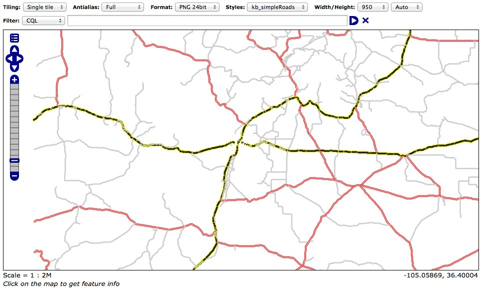

### Attribute Filter Example - Styled NM Roads - NM Highways

```xml
<!-- New Mexico Highways -->
<Rule>
  <Title>NM Highways</Title>
  <ogc:Filter>
    <ogc:PropertyIsEqualTo>
      <ogc:PropertyName>TYPE</ogc:PropertyName>
      <ogc:Literal>State Highway</ogc:Literal>
    </ogc:PropertyIsEqualTo>
  </ogc:Filter>
  <LineSymbolizer>
    <Stroke>
      <CssParameter name="stroke">
        <ogc:Literal>#CCCCCC</ogc:Literal>
      </CssParameter>
      <CssParameter name="stroke-width">
        <ogc:Literal>2</ogc:Literal>
      </CssParameter>
    </Stroke>
  </LineSymbolizer>
</Rule>
```

### Attribute Filter Example - Styled NM Roads - US Highways

```xml
<!-- US Highways -->
<Rule>
  <Title>US Highways</Title>
  <ogc:Filter>
    <ogc:PropertyIsEqualTo>
        <ogc:PropertyName>TYPE</ogc:PropertyName>
        <ogc:Literal>US Highway</ogc:Literal>
    </ogc:PropertyIsEqualTo>
  </ogc:Filter>
  <LineSymbolizer>
    <Stroke>
      <CssParameter name="stroke">
        <ogc:Literal>#ff0000</ogc:Literal>
      </CssParameter>
      <CssParameter name="stroke-width">
        <ogc:Literal>3</ogc:Literal>
      </CssParameter>
    </Stroke>
  </LineSymbolizer>
  <LineSymbolizer>
    <Stroke>
      <CssParameter name="stroke">
        <ogc:Literal>#CCCCCC</ogc:Literal>
      </CssParameter>
      <CssParameter name="stroke-width">
        <ogc:Literal>1</ogc:Literal>
      </CssParameter>
    </Stroke>
  </LineSymbolizer>
</Rule>
```

### Attribute Filter Example - Styled NM Roads - Interstates

```xml
<!-- Interstate Highways -->
<Rule>
  <Title>Interstates</Title>
  <ogc:Filter>
    <ogc:PropertyIsEqualTo>
      <ogc:PropertyName>TYPE</ogc:PropertyName>
      <ogc:Literal>Interstate</ogc:Literal>
    </ogc:PropertyIsEqualTo>
  </ogc:Filter>
  <LineSymbolizer>
    <Stroke>
      <CssParameter name="stroke">
        <ogc:Literal>#fcff00</ogc:Literal>
      </CssParameter>
      <CssParameter name="stroke-width">
        <ogc:Literal>5</ogc:Literal>
      </CssParameter>
    </Stroke>
  </LineSymbolizer>
  <LineSymbolizer>
    <Stroke>
      <CssParameter name="stroke">
        <ogc:Literal>#222222</ogc:Literal>
      </CssParameter>
      <CssParameter name="stroke-width">
        <ogc:Literal>3</ogc:Literal>
      </CssParameter>
    </Stroke>
  </LineSymbolizer>
</Rule>
```

### Attribute Filter with Scale Factor

The only change needed to introduce scale-dependencies into styles is to include `<MaxScaleDenominator>` or `<MinScaleDenominator>` elements within a rule where they should be applied. These elements should be placed just before the symbolizer element so that GeoServer can properly validate the provided SLD.

### Attribute Filter with Scale Factor - 1 to 9,000,000 Scale Map

Full SLD

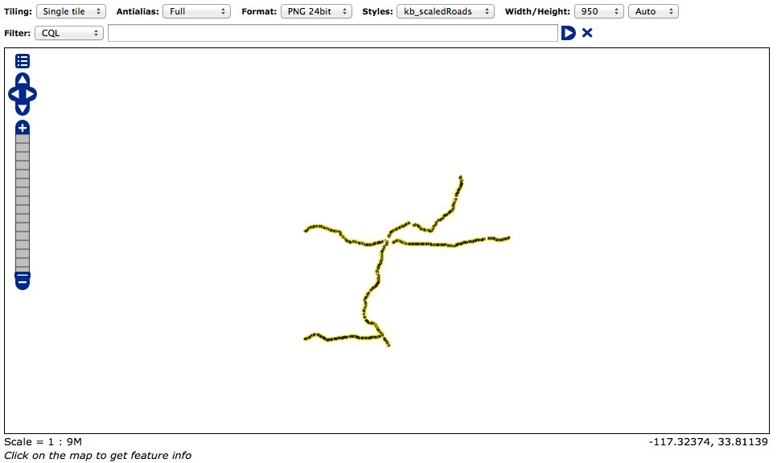

### Attribute Filter with Scale Factor - 1 to 2,000,000 Scale Map

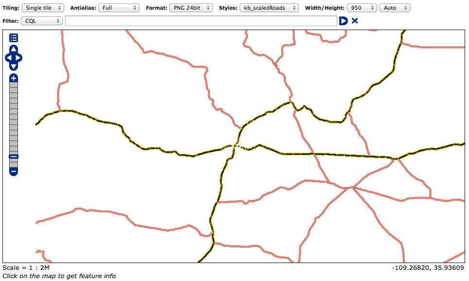

### Attribute Filter with Scale Factor - 1 to 586,000 Scale Map

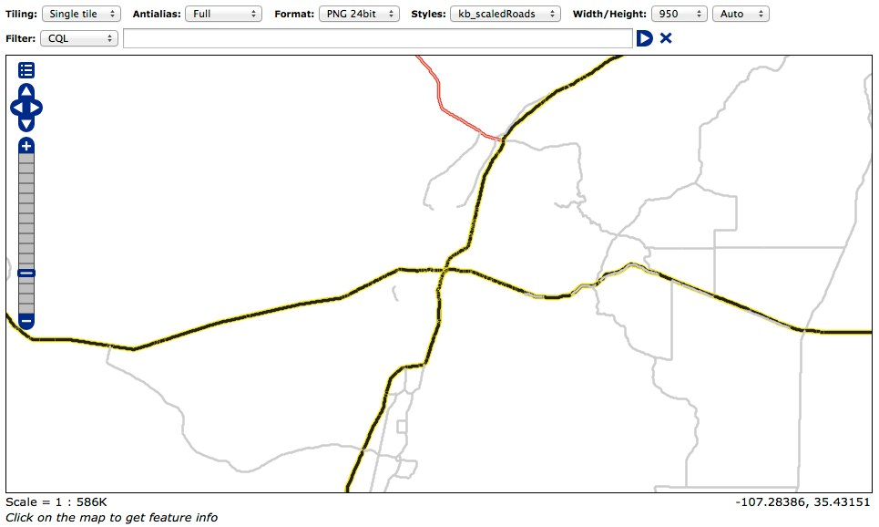

### Attribute Filter with Scale Factor - Scaled NM Roads - NM Highways

```xml
<!-- New Mexico Highways -->
<Rule>
  <Title>NM Highways</Title>
  <ogc:Filter>
    <ogc:PropertyIsEqualTo>
      <ogc:PropertyName>TYPE</ogc:PropertyName>
      <ogc:Literal>State Highway</ogc:Literal>
    </ogc:PropertyIsEqualTo>
  </ogc:Filter>
  <MaxScaleDenominator>1000000</MaxScaleDenominator>
  <LineSymbolizer>
    <Stroke>
      <CssParameter name="stroke">
        <ogc:Literal>#CCCCCC</ogc:Literal>
      </CssParameter>
      <CssParameter name="stroke-width">
        <ogc:Literal>2</ogc:Literal>
      </CssParameter>
    </Stroke>
  </LineSymbolizer>
</Rule>
```

### Attribute Filter with Scale Factor - Scaled NM Roads - US Highways

```xml
<!-- US Highways -->
<Rule>
  <Title>US Highways</Title>
  <ogc:Filter>
    <ogc:PropertyIsEqualTo>
        <ogc:PropertyName>TYPE</ogc:PropertyName>
        <ogc:Literal>US Highway</ogc:Literal>
    </ogc:PropertyIsEqualTo>
  </ogc:Filter>
  <MaxScaleDenominator>5000000</MaxScaleDenominator>
  <LineSymbolizer>
    <Stroke>
      <CssParameter name="stroke">
        <ogc:Literal>#ff0000</ogc:Literal>
      </CssParameter>
      <CssParameter name="stroke-width">
        <ogc:Literal>3</ogc:Literal>
      </CssParameter>
    </Stroke>
  </LineSymbolizer>
  <LineSymbolizer>
    <Stroke>
      <CssParameter name="stroke">
        <ogc:Literal>#CCCCCC</ogc:Literal>
      </CssParameter>
      <CssParameter name="stroke-width">
        <ogc:Literal>1</ogc:Literal>
      </CssParameter>
    </Stroke>
  </LineSymbolizer>
</Rule>
```

### Attribute Filter with Scale Factor - Scaled NM Roads - Interstates

This is unchanged from the previous example as the Interstates are visible at all scales.

```xml
<!-- Interstate Highways -->
<Rule>
  <Title>Interstates</Title>
  <ogc:Filter>
    <ogc:PropertyIsEqualTo>
      <ogc:PropertyName>TYPE</ogc:PropertyName>
      <ogc:Literal>Interstate</ogc:Literal>
    </ogc:PropertyIsEqualTo>
  </ogc:Filter>
  <LineSymbolizer>
    <Stroke>
      <CssParameter name="stroke">
        <ogc:Literal>#fcff00</ogc:Literal>
      </CssParameter>
      <CssParameter name="stroke-width">
        <ogc:Literal>5</ogc:Literal>
      </CssParameter>
    </Stroke>
  </LineSymbolizer>
  <LineSymbolizer>
    <Stroke>
      <CssParameter name="stroke">
        <ogc:Literal>#222222</ogc:Literal>
      </CssParameter>
      <CssParameter name="stroke-width">
        <ogc:Literal>3</ogc:Literal>
      </CssParameter>
    </Stroke>
  </LineSymbolizer>
</Rule>
```

### Demonstrations

Class GeoServer Instance: http://geog485.unm.edu:8080/geoserver/web/

SLD Creation Using QGIS: Link to the [QGIS Vector Properties Dialog](http://www.qgis.org/en/docs/user_manual/working_with_vector/vector_properties.html?highlight=sld) Documentation.